# Part I - Prosper Loan Data Exploration

## by Lawal Rasheed

## Introduction

> This file examines a dataset that contains Loan Amount, Stated Monthly Income, Debt-Income-Ratio, Prosper Score and many others for approximately 114,000 rows of loan data. See this [data dictionary](https://docs.google.com/spreadsheets/d/1gDyi_L4UvIrLTEC6Wri5nbaMmkGmLQBk-Yx3z0XDEtI/edit#gid=0) to understand the dataset's variables.

## Preliminary Wrangling

## Gather

```python
# import all packages and set plots to be embedded inline
import numpy as np
import pandas as pd
import matplotlib.pyplot as plt
import seaborn as sb

%matplotlib inline
```

```python
loandata = pd.read_csv('C:/Users/Rasheed Lawal/Downloads/prosperLoanData.csv')
```

```python
print(loandata.shape)
print(loandata.dtypes)
print(loandata.head(10))
```

```
(113937, 81)
ListingKey                      object
ListingNumber                    int64
ListingCreationDate             object
CreditGrade                     object
Term                             int64
                                ...
PercentFunded                  float64
Recommendations                  int64
InvestmentFromFriendsCount       int64
InvestmentFromFriendsAmount    float64
Investors                        int64
Length: 81, dtype: object
                ListingKey  ListingNumber            ListingCreationDate  \
0  1021339766868145413AB3B         193129  2007-08-26 19:09:29.263000000
```

[output cut: 71 more lines]

```python
loandata.columns
```

```
Index(['ListingKey', 'ListingNumber', 'ListingCreationDate', 'CreditGrade',
       'Term', 'LoanStatus', 'ClosedDate', 'BorrowerAPR', 'BorrowerRate',
       'LenderYield', 'EstimatedEffectiveYield', 'EstimatedLoss',
       'EstimatedReturn', 'ProsperRating (numeric)', 'ProsperRating (Alpha)',
       'ProsperScore', 'ListingCategory (numeric)', 'BorrowerState',
       'Occupation', 'EmploymentStatus', 'EmploymentStatusDuration',
       'IsBorrowerHomeowner', 'CurrentlyInGroup', 'GroupKey',
       'DateCreditPulled', 'CreditScoreRangeLower', 'CreditScoreRangeUpper',
       'FirstRecordedCreditLine', 'CurrentCreditLines', 'OpenCreditLines',
       'TotalCreditLinespast7years', 'OpenRevolvingAccounts',
       'OpenRevolvingMonthlyPayment', 'InquiriesLast6Months', 'TotalInquiries',
       'CurrentDelinquencies', 'AmountDelinquent', 'DelinquenciesLast7Years',
       'PublicRecordsLast10Years', 'PublicRecordsLast12Months',
       'RevolvingCreditBalance', 'BankcardUtilization',
       'AvailableBankcardCredit', 'TotalTrades',
       'TradesNeverDelinquent (percentage)', 'TradesOpenedLast6Months',
       'DebtToIncomeRatio', 'IncomeRange', 'IncomeVerifiable',
       'StatedMonthlyIncome', 'LoanKey', 'TotalProsperLoans',
       'TotalProsperPaymentsBilled', 'OnTimeProsperPayments',
       'ProsperPaymentsLessThanOneMonthLate',
       'ProsperPaymentsOneMonthPlusLate', 'ProsperPrincipalBorrowed',
       'ProsperPrincipalOutstanding', 'ScorexChangeAtTimeOfListing',
       'LoanCurrentDaysDelinquent', 'LoanFirstDefaultedCycleNumber',
       'LoanMonthsSinceOrigination', 'LoanNumber', 'LoanOriginalAmount',
       'LoanOriginationDate', 'LoanOriginationQuarter', 'MemberKey',
       'MonthlyLoanPayment', 'LP_CustomerPayments',
       'LP_CustomerPrincipalPayments', 'LP_InterestandFees', 'LP_ServiceFees',
       'LP_CollectionFees', 'LP_GrossPrincipalLoss', 'LP_NetPrincipalLoss',
       'LP_NonPrincipalRecoverypayments', 'PercentFunded', 'Recommendations',
       'InvestmentFromFriendsCount', 'InvestmentFromFriendsAmount',
       'Investors'],
      dtype='object')
```

### **Subsetting the dataframe**

Columns that will be used for the data exploration and analysis will pe picked into a separate dataframe.

```python
loandata_sub = loandata[['ListingNumber', 'Term', 'LoanStatus', 'IncomeRange', 'ProsperRating (Alpha)', 'ProsperScore', 'ListingCategory (numeric)', 'BorrowerState', 'Occupation', 'EmploymentStatus', 'EmploymentStatusDuration', 'DebtToIncomeRatio', 'IsBorrowerHomeowner', 'StatedMonthlyIncome', 'LoanOriginalAmount', 'LoanOriginationDate', 'LoanOriginationQuarter', 'MonthlyLoanPayment']]
```

## Assess

```python
# checking the first five rows
loandata_sub.head()
```

|  | ListingNumber | Term | LoanStatus | IncomeRange | ProsperRating (Alpha) | ProsperScore | ListingCategory (numeric) | BorrowerState | Occupation | EmploymentStatus | EmploymentStatusDuration | DebtToIncomeRatio | IsBorrowerHomeowner | StatedMonthlyIncome | LoanOriginalAmount | LoanOriginationDate | LoanOriginationQuarter | MonthlyLoanPayment |
| --- | --- | --- | --- | --- | --- | --- | --- | --- | --- | --- | --- | --- | --- | --- | --- | --- | --- | --- |
| 0 | 193129 | 36 | Completed | $25,000-49,999 | NaN | NaN | 0 | CO | Other | Self-employed | 2.0 | 0.17 | True | 3083.333333 | 9425 | 2007-09-12 00:00:00 | Q3 2007 | 330.43 |
| 1 | 1209647 | 36 | Current | $50,000-74,999 | A | 7.0 | 2 | CO | Professional | Employed | 44.0 | 0.18 | False | 6125.000000 | 10000 | 2014-03-03 00:00:00 | Q1 2014 | 318.93 |
| 2 | 81716 | 36 | Completed | Not displayed | NaN | NaN | 0 | GA | Other | Not available | NaN | 0.06 | False | 2083.333333 | 3001 | 2007-01-17 00:00:00 | Q1 2007 | 123.32 |
| 3 | 658116 | 36 | Current | $25,000-49,999 | A | 9.0 | 16 | GA | Skilled Labor | Employed | 113.0 | 0.15 | True | 2875.000000 | 10000 | 2012-11-01 00:00:00 | Q4 2012 | 321.45 |
| 4 | 909464 | 36 | Current | $100,000+ | D | 4.0 | 2 | MN | Executive | Employed | 44.0 | 0.26 | True | 9583.333333 | 15000 | 2013-09-20 00:00:00 | Q3 2013 | 563.97 |

```python
# Getting a concise summary of the dataset
loandata_sub.info()
```

```
<class 'pandas.core.frame.DataFrame'>
RangeIndex: 113937 entries, 0 to 113936
Data columns (total 18 columns):
 #   Column                     Non-Null Count   Dtype
---  ------                     --------------   -----
 0   ListingNumber              113937 non-null  int64
 1   Term                       113937 non-null  int64
 2   LoanStatus                 113937 non-null  object
 3   IncomeRange                113937 non-null  object
 4   ProsperRating (Alpha)      84853 non-null   object
 5   ProsperScore               84853 non-null   float64
 6   ListingCategory (numeric)  113937 non-null  int64
 7   BorrowerState              108422 non-null  object
 8   Occupation                 110349 non-null  object
 9   EmploymentStatus           111682 non-null  object
 10  EmploymentStatusDuration   106312 non-null  float64
 11  DebtToIncomeRatio          105383 non-null  float64
 12  IsBorrowerHomeowner        113937 non-null  bool
 13  StatedMonthlyIncome        113937 non-null  float64
 14  LoanOriginalAmount         113937 non-null  int64
 15  LoanOriginationDate        113937 non-null  object
 16  LoanOriginationQuarter     113937 non-null  object
 17  MonthlyLoanPayment         113937 non-null  float64
dtypes: bool(1), float64(5), int64(4), object(8)
memory usage: 14.9+ MB
```

```python
# Checking for null values
loandata_sub.isnull().sum()
```

```
ListingNumber                    0
Term                             0
LoanStatus                       0
IncomeRange                      0
ProsperRating (Alpha)        29084
ProsperScore                 29084
ListingCategory (numeric)        0
BorrowerState                 5515
Occupation                    3588
EmploymentStatus              2255
EmploymentStatusDuration      7625
DebtToIncomeRatio             8554
IsBorrowerHomeowner              0
StatedMonthlyIncome              0
LoanOriginalAmount               0
LoanOriginationDate              0
LoanOriginationQuarter           0
MonthlyLoanPayment               0
dtype: int64
```

```python
# Checking for duplicates
loandata_sub.duplicated().sum()
```

```
0
```

```python
# Getting the number of unique values in the LoanStatus column
loandata_sub.LoanStatus.value_counts()
```

```
Current                   56576
Completed                 38074
Chargedoff                11992
Defaulted                  5018
Past Due (1-15 days)        806
Past Due (31-60 days)       363
Past Due (61-90 days)       313
Past Due (91-120 days)      304
Past Due (16-30 days)       265
FinalPaymentInProgress      205
Past Due (>120 days)         16
Cancelled                     5
Name: LoanStatus, dtype: int64
```

```python
# Getting the unique values in ProsperRating (Alpha) column
loandata_sub['ProsperRating (Alpha)'].value_counts()
```

```
C     18345
B     15581
A     14551
D     14274
E      9795
HR     6935
AA     5372
Name: ProsperRating (Alpha), dtype: int64
```

```python
# Checking the number of null values in the ProsperRating (Alpha) column
loandata_sub['ProsperRating (Alpha)'].isnull().sum()
```

```
29084
```

```python
# Getting the count of unique values in the ListingCategory (numeric) column
loandata_sub['ListingCategory (numeric)'].value_counts()
```

```
1     58308
0     16965
7     10494
2      7433
3      7189
6      2572
4      2395
13     1996
15     1522
18      885
14      876
20      771
19      768
5       756
16      304
11      217
8       199
10       91
9        85
12       59
17       52
Name: ListingCategory (numeric), dtype: int64
```

```python
# Getting the unique values in EmploymentStatus column
loandata_sub['EmploymentStatus'].value_counts()
```

```
Employed         67322
Full-time        26355
Self-employed     6134
Not available     5347
Other             3806
Part-time         1088
Not employed       835
Retired            795
Name: EmploymentStatus, dtype: int64
```

```python
# Getting the unique values in the IsBorrowerHomeowner column
loandata_sub['IsBorrowerHomeowner'].value_counts()
```

```
True     57478
False    56459
Name: IsBorrowerHomeowner, dtype: int64
```

```python
# Getting the unique values in the ProsperScore column
loandata_sub['ProsperScore'].value_counts()
```

```
4.0     12595
6.0     12278
8.0     12053
7.0     10597
5.0      9813
3.0      7642
9.0      6911
2.0      5766
10.0     4750
11.0     1456
1.0       992
Name: ProsperScore, dtype: int64
```

```python
# Getting the count of unique values in the StatedMonthlyIncome column
loandata_sub['StatedMonthlyIncome'].value_counts()
```

```
4166.666667     3526
5000.000000     3389
3333.333333     2917
3750.000000     2428
5416.666667     2374
                ...
7069.916667        1
4266.333333        1
2211.750000        1
7032.916667        1
18756.000000       1
Name: StatedMonthlyIncome, Length: 13502, dtype: int64
```

Assessments

1. Missing values in ProsperRating (Alpha), ProsperScore, BorrowerState, Occupation, EmploymentStatus, and EmploymentStatusDuration columns.
2. Incorrect datatypes in ListingNumber, LoanStatus, IncomeRange, ProsperRating (Alpha), ProsperScore, ListingCategory, EmploymentStatus and LoanOriginationDate should be converted into their correct datatypes.
3. Replace True with 'Home Owner' and False with 'None Home Owner', and then change into a categorical datatype.
4. Round StatedMonthlyIncome to the nearest dollar.

```python
# Creating a copy of the dataframe
loandata_clean = loandata_sub.copy()
```

## Clean

**Issue #1:**

```python
# Filtering to get only rows where ProsperRating (Alpha) is not null
loandata_clean = loandata_clean[loandata_clean['ProsperRating (Alpha)'].notnull()]
```

```python
# Filtering to get only rows where DebtToIncomeRatio is not null
loandata_clean = loandata_clean[loandata_clean['DebtToIncomeRatio'].notnull()]
```

```python
# Filtering to get only rows where EmploymentStatusDuration is not null
loandata_clean = loandata_clean[loandata_clean['EmploymentStatusDuration'].notnull()]
```

Test

```python
loandata_clean['ProsperRating (Alpha)'].isnull().sum()
```

```
0
```

```python
loandata_clean['DebtToIncomeRatio'].isnull().sum()
```

```
0
```

```python
loandata_clean['EmploymentStatusDuration'].isnull().sum()
```

```
0
```

**Issue #2:**

```python
# Rounding off StatedMonthlyIncome to 0 decimals
loandata_clean.StatedMonthlyIncome = loandata_clean.StatedMonthlyIncome.round(decimals=0)
loandata_clean.head()
```

|  | ListingNumber | Term | LoanStatus | IncomeRange | ProsperRating (Alpha) | ProsperScore | ListingCategory (numeric) | BorrowerState | Occupation | EmploymentStatus | EmploymentStatusDuration | DebtToIncomeRatio | IsBorrowerHomeowner | StatedMonthlyIncome | LoanOriginalAmount | LoanOriginationDate | LoanOriginationQuarter | MonthlyLoanPayment |
| --- | --- | --- | --- | --- | --- | --- | --- | --- | --- | --- | --- | --- | --- | --- | --- | --- | --- | --- |
| 1 | 1209647 | 36 | Current | $50,000-74,999 | A | 7.0 | 2 | CO | Professional | Employed | 44.0 | 0.18 | False | 6125.0 | 10000 | 2014-03-03 00:00:00 | Q1 2014 | 318.93 |
| 3 | 658116 | 36 | Current | $25,000-49,999 | A | 9.0 | 16 | GA | Skilled Labor | Employed | 113.0 | 0.15 | True | 2875.0 | 10000 | 2012-11-01 00:00:00 | Q4 2012 | 321.45 |
| 4 | 909464 | 36 | Current | $100,000+ | D | 4.0 | 2 | MN | Executive | Employed | 44.0 | 0.26 | True | 9583.0 | 15000 | 2013-09-20 00:00:00 | Q3 2013 | 563.97 |
| 5 | 1074836 | 60 | Current | $100,000+ | B | 10.0 | 1 | NM | Professional | Employed | 82.0 | 0.36 | True | 8333.0 | 15000 | 2013-12-24 00:00:00 | Q4 2013 | 342.37 |
| 6 | 750899 | 36 | Current | $25,000-49,999 | E | 2.0 | 1 | KS | Sales - Retail | Employed | 172.0 | 0.27 | False | 2083.0 | 3000 | 2013-04-18 00:00:00 | Q2 2013 | 122.67 |

Test

```python
loandata_clean['StatedMonthlyIncome'].value_counts()
```

```
4167.0     2429
5000.0     2307
3333.0     1916
5833.0     1830
5417.0     1770
           ...
8653.0        1
36250.0       1
1602.0        1
2166.0        1
18756.0       1
Name: StatedMonthlyIncome, Length: 6255, dtype: int64
```

### Issue #3:

```python
# Replacing True with Home Owner and False with Not Home Owner
loandata_clean.IsBorrowerHomeowner = loandata_clean.IsBorrowerHomeowner.map({True: 'True', False: 'False'})
loandata_clean.IsBorrowerHomeowner.replace('True', 'Home Owner', inplace=True)
loandata_clean.IsBorrowerHomeowner.replace('False', 'Not Home Owner', inplace=True)
```

Test

```python
loandata_clean['IsBorrowerHomeowner'].value_counts()
```

```
Home Owner        42058
Not Home Owner    35485
Name: IsBorrowerHomeowner, dtype: int64
```

### Issue #4:

```python
# Filling null values in Occupation column with None
loandata_clean.Occupation = loandata_clean.Occupation.fillna('None')
```

```python
loandata_clean.Occupation.isnull().sum()
```

```
0
```

```python
from datetime import datetime
```

```python
loandata_clean.LoanOriginationDate = pd.to_datetime(loandata_clean.LoanOriginationDate)
```

```python
loandata_clean['LoanOriginationYear'] = loandata_clean['LoanOriginationDate'].dt.year
loandata_clean['LoanOriginationMonth'] = loandata_clean['LoanOriginationDate'].dt.month
loandata_clean['LoanOriginationTime'] = loandata_clean['LoanOriginationDate'].dt.time
```

Test

```python
loandata_clean = loandata_clean.drop(['LoanOriginationDate'], axis=1)
loandata_clean.head()
```

|  | ListingNumber | Term | LoanStatus | IncomeRange | ProsperRating (Alpha) | ProsperScore | ListingCategory (numeric) | BorrowerState | Occupation | EmploymentStatus | EmploymentStatusDuration | DebtToIncomeRatio | IsBorrowerHomeowner | StatedMonthlyIncome | LoanOriginalAmount | LoanOriginationQuarter | MonthlyLoanPayment | LoanOriginationYear | LoanOriginationMonth | LoanOriginationTime |
| --- | --- | --- | --- | --- | --- | --- | --- | --- | --- | --- | --- | --- | --- | --- | --- | --- | --- | --- | --- | --- |
| 1 | 1209647 | 36 | Current | $50,000-74,999 | A | 7.0 | 2 | CO | Professional | Employed | 44.0 | 0.18 | Not Home Owner | 6125.0 | 10000 | Q1 2014 | 318.93 | 2014 | 3 | 00:00:00 |
| 3 | 658116 | 36 | Current | $25,000-49,999 | A | 9.0 | 16 | GA | Skilled Labor | Employed | 113.0 | 0.15 | Home Owner | 2875.0 | 10000 | Q4 2012 | 321.45 | 2012 | 11 | 00:00:00 |
| 4 | 909464 | 36 | Current | $100,000+ | D | 4.0 | 2 | MN | Executive | Employed | 44.0 | 0.26 | Home Owner | 9583.0 | 15000 | Q3 2013 | 563.97 | 2013 | 9 | 00:00:00 |
| 5 | 1074836 | 60 | Current | $100,000+ | B | 10.0 | 1 | NM | Professional | Employed | 82.0 | 0.36 | Home Owner | 8333.0 | 15000 | Q4 2013 | 342.37 | 2013 | 12 | 00:00:00 |
| 6 | 750899 | 36 | Current | $25,000-49,999 | E | 2.0 | 1 | KS | Sales - Retail | Employed | 172.0 | 0.27 | Not Home Owner | 2083.0 | 3000 | Q2 2013 | 122.67 | 2013 | 4 | 00:00:00 |

```python
# Replacing the numbers in LoanOriginationMonth with actual months
loandata_clean['LoanOriginationMonth'] = loandata_clean['LoanOriginationMonth'].replace([1,2,3,4,5,6,7,8,9,10,11,12], ['January', 'February', 'March', 'April', 'May', 'June', 'July', 'August', 'September', 'October', 'November', 'December'])
```

```python
loandata_clean['LoanOriginationMonth'].value_counts()
```

```
January      8468
October      8096
December     8078
November     7444
February     7127
September    6314
August       6082
July         5803
March        5471
June         5415
May          4856
April        4389
Name: LoanOriginationMonth, dtype: int64
```

```python
# Convert LoanStatus, ProsperRating (Alpha), ProsperScore into ordered categorical types
ordinal_var_dict = {'LoanStatus': ['Cancelled',  'Chargedoff', 'Completed', 'Current', 'Defaulted', 'FinalPaymentInProgress'
                                   ,'Past Due (1-15 days)', 'Past Due (16-30 days)', 'Past Due (31-60 days)',
                                   'Past Due (61-90 days)', 'Past Due (91-120 days)', 'Past Due (>120 days)'],
                    'ProsperRating (Alpha)': ['HR', 'E', 'D', 'C', 'B', 'A', 'AA'],
                    'ProsperScore': [1, 2, 3, 4, 5, 6, 7, 8, 9, 10, 11],
                   'LoanOriginationMonth': ['January','Febuary', 'March','April','May','June','July','August','September',
                                            'October','November','December'],
                   'LoanOriginationYear' : [2009, 2010, 2011, 2012, 2013, 2014],
                   'IncomeRange' : ['Not employed', '$1-24,999', '$25,000-49,999', '$50,000-74,999',
                                   '$75,000-99,999','$100,000+']}

for var in ordinal_var_dict:
    ordered_var = pd.api.types.CategoricalDtype(ordered = True, categories = ordinal_var_dict[var])
    loandata_clean[var] = loandata_clean[var].astype(ordered_var)
```

```python
# Converting datatypes
loandata_clean.ListingNumber = loandata_clean.ListingNumber.astype(str)
loandata_clean['ListingCategory (numeric)'] = loandata_clean['ListingCategory (numeric)'].astype('category')
loandata_clean.IsBorrowerHomeowner = loandata_clean.IsBorrowerHomeowner.astype('category')
loandata_clean.EmploymentStatus = loandata_clean.EmploymentStatus.astype('category')
```

Test

```python
loandata_clean.info()
```

```
<class 'pandas.core.frame.DataFrame'>
Int64Index: 77543 entries, 1 to 113936
Data columns (total 20 columns):
 #   Column                     Non-Null Count  Dtype
---  ------                     --------------  -----
 0   ListingNumber              77543 non-null  object
 1   Term                       77543 non-null  int64
 2   LoanStatus                 77543 non-null  category
 3   IncomeRange                77543 non-null  category
 4   ProsperRating (Alpha)      77543 non-null  category
 5   ProsperScore               77543 non-null  category
 6   ListingCategory (numeric)  77543 non-null  category
 7   BorrowerState              77543 non-null  object
 8   Occupation                 77543 non-null  object
 9   EmploymentStatus           77543 non-null  category
 10  EmploymentStatusDuration   77543 non-null  float64
 11  DebtToIncomeRatio          77543 non-null  float64
 12  IsBorrowerHomeowner        77543 non-null  category
 13  StatedMonthlyIncome        77543 non-null  float64
 14  LoanOriginalAmount         77543 non-null  int64
 15  LoanOriginationQuarter     77543 non-null  object
 16  MonthlyLoanPayment         77543 non-null  float64
 17  LoanOriginationYear        77543 non-null  category
 18  LoanOriginationMonth       70416 non-null  category
 19  LoanOriginationTime        77543 non-null  object
dtypes: category(9), float64(4), int64(2), object(5)
memory usage: 7.8+ MB
```

```python
# Saving to a csv file
loandata_clean.to_csv('ProsperLoanData.csv')
```

### What is/are the main feature(s) of interest in your dataset?

> The main feature of interest in the dataset is the LoanOriginalAmount as there is an assumption of a borrower and wanting to figure out what determines the maximum loan amount that will be given to a borrower.

### What features in the dataset do you think will help support your investigation into your feature(s) of interest?

> The features in the dataset that I think will support my investigation includes:
> 1. StatedMonthlyIncome(the higher the income, the higher the LoanOriginalAmount).
> 2. DebtToIncomeRatio.
> 3. ProsperScore.
> 4. Being a Home Owner will also have a positive effect on LoanOriginalAmount.

## Univariate Exploration

## Question 1:

How is the main variable of interest - 'LoanOriginalAmount' distributed?

## Visualization

```python
# Choosing color palette
base_color = sb.color_palette()[0]
```

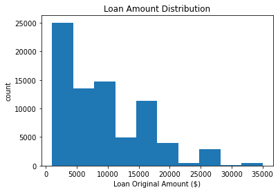

```python
# Plotting a histogram for LoanOriginalAmount
plt.hist(data=loandata_clean, x='LoanOriginalAmount');
plt.xlabel('Loan Original Amount ($)');
plt.ylabel('count');
plt.title('Loan Amount Distribution');
```

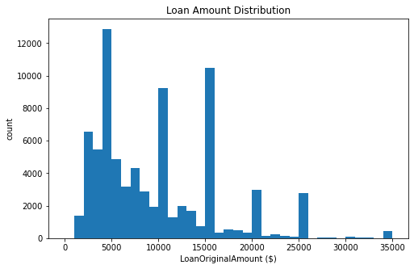

```python
# Standard scaled plotting
binsize = 1000
bins = np.arange(0, loandata_clean['LoanOriginalAmount'].max()+binsize, binsize)

plt.figure(figsize=[8, 5])
plt.hist(data = loandata_clean, x = 'LoanOriginalAmount', bins = bins)
plt.xlabel('LoanOriginalAmount ($)')
plt.ylabel('count')
plt.title('Loan Amount Distribution');
plt.show()
```

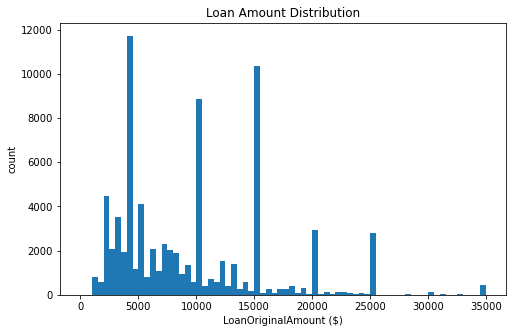

```python
# Using a smaller bin size
binsize = 500
bins = np.arange(0, loandata_clean['LoanOriginalAmount'].max()+binsize, binsize)

plt.figure(figsize=[8, 5])
plt.hist(data = loandata_clean, x = 'LoanOriginalAmount', bins = bins)
plt.xlabel('LoanOriginalAmount ($)')
plt.ylabel('count')
plt.title('Loan Amount Distribution');
plt.show()
```

## Question 2:

Which IncomeRanges are getting the most loan amount?

## Visualization

```python
def splitString(string):
    '''splitString() - split a string, adding a space before an uppercase letter'''
    # loop through each character
    # if a character is lower case, leave it as is
    # otherwise put a space before it
    return ''.join([x if x.islower() else f" {x}" for x in string])
```

```python
def myCountPlot(loandata_clean, xVar, color=0, order=None, figsize=[14, 6]):
    '''prints/returns a plotted bar chart'''
    # set plot dimensions
    plt.figure(figsize=figsize)
    # plot
    sb.countplot(data=loandata_clean, x = xVar, edgecolor='black', color=sb.color_palette()[color], order=order);
    # clean up variable name after plotting
    xVar=splitString(xVar).replace("_", " ") # replace _ with a space
    # add title
    plt.title(f'''Distribution of {xVar}'''.title())
    # add xlabel
    plt.xlabel(xVar.title())
    # add ylabel
    plt.ylabel('Frequency'.title())
```

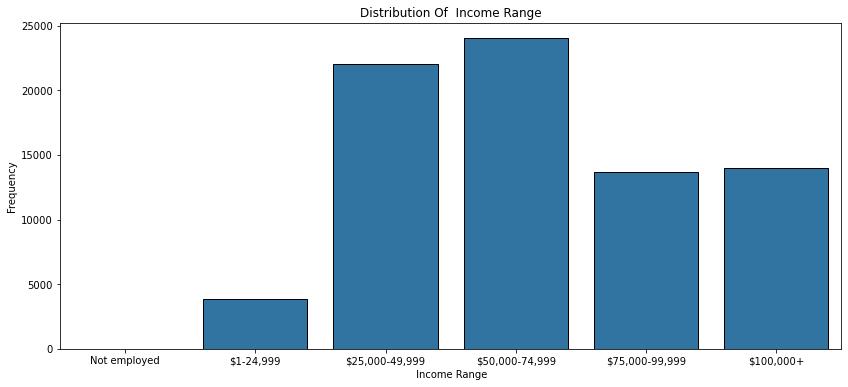

```python
# call plot function
myCountPlot(loandata_clean, 'IncomeRange')
```

## Question 3:

What is the distribution of the Loan Term?

## Visualization

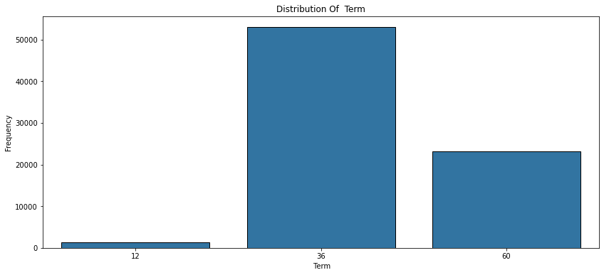

```python
# calling plot function
myCountPlot(loandata_clean, 'Term')
```

## Observation

The visual displayed above shows that majority of the Loan is termed at 36 months i.e. three years.

## Question 4:

How is the StatedMonthlyIncome distributed?

## Visualization

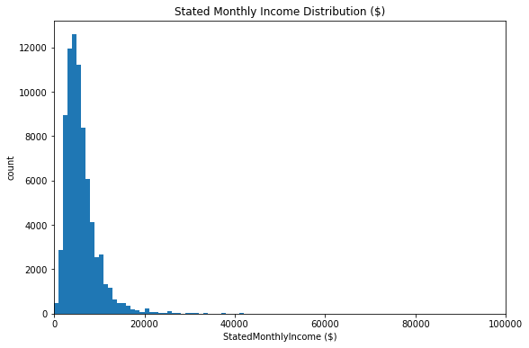

```python
# Standard scale plotting
binsize = 1000
bins = np.arange(0, loandata_clean['StatedMonthlyIncome'].max()+binsize, binsize)
plt.figure(figsize=[9, 6])
plt.hist(data = loandata_clean, x = 'StatedMonthlyIncome', bins=bins)
plt.xlabel('StatedMonthlyIncome ($)')
plt.ylabel('count')
plt.title('Stated Monthly Income Distribution ($)');
plt.xlim(0, 100000)
plt.show()
```

[output not shown]

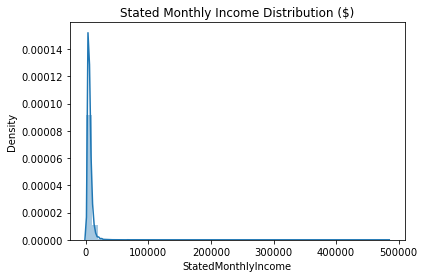

```python
# Using seaborns distplot function
sb.distplot(loandata_clean.StatedMonthlyIncome)
plt.title('Stated Monthly Income Distribution ($)');
```

A long tail distribution is observed and this could indicate the presence of outliers.

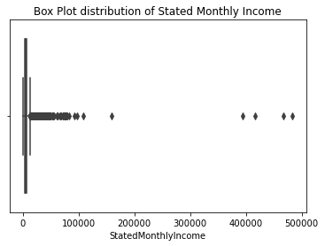

```python
# Using a box plot with StatedMonthlyIncome variable to check for outliers
sb.boxplot(x = loandata_clean['StatedMonthlyIncome'])
plt.title('Box Plot distribution of Stated Monthly Income');
```

There is presence of outliers as observed. The IQR method will be used to detect and remove the outliers.

```python
# Using IQR method to detect outliers
Q1 = loandata_clean['StatedMonthlyIncome'].quantile(0.25)
Q3 = loandata_clean['StatedMonthlyIncome'].quantile(0.75)
IQR = Q3 - Q1
LowerLimit = Q1 - 1.5*IQR  # data which falls below this is an outlier
UpperLimit = Q3 + 1.5*IQR  # data which falls above this is an outlier
print(LowerLimit, UpperLimit)
```

```
-1918.0 12618.0
```

```python
# Shape before removing outlier
loandata_clean.shape
```

```
(77543, 20)
```

```python
# Removing outliers(trimming)
loandata_clean = loandata_clean[loandata_clean['StatedMonthlyIncome'] < UpperLimit]
```

```python
# Shape after removing outliers
loandata_clean.shape
```

```
(74035, 20)
```

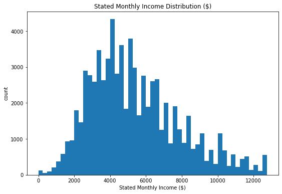

```python
# Plotting an histogram with the trimmed dataframe
binsize = 250
bins = np.arange(0, loandata_clean['StatedMonthlyIncome'].max()+binsize, binsize)
plt.figure(figsize=[9, 6])
plt.hist(data = loandata_clean, x = 'StatedMonthlyIncome', bins=bins)
plt.xlabel('Stated Monthly Income ($)')
plt.ylabel('count')
plt.title('Stated Monthly Income Distribution ($)');
plt.show()
```

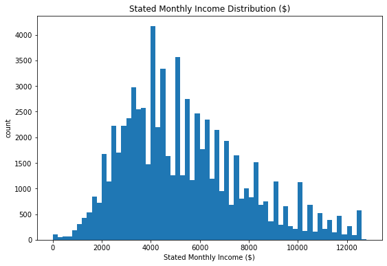

```python
# Using a reduced bin size
binsize = 200
bins = np.arange(0, loandata_clean['StatedMonthlyIncome'].max()+binsize, binsize)
plt.figure(figsize=[9, 6])
plt.hist(data = loandata_clean, x = 'StatedMonthlyIncome', bins=bins)
plt.xlabel('Stated Monthly Income ($)')
plt.ylabel('count')
plt.title('Stated Monthly Income Distribution ($)');
plt.show()
```

## Observation

It can be observed from the visuals above that the Stated Monthly Income had a long-tailed distribution, showing a lot of people earning on the low end. A significant was also attained when the outliers have been removed, which was at around 4,000 dollars. The little peak at $0 represents people that are not employed.

## Question 5:

Is there a threshold value in the DebtToIncomeRatio for borrowers, and what DebtToIncomeRatio value do standard loan lenders prefer?

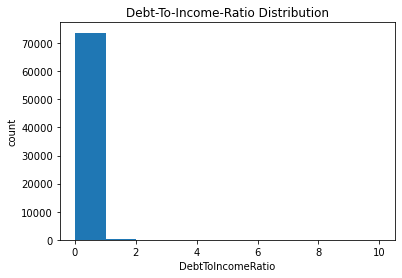

```python
# Plotting a histogram for DebtToIncomeRatio distribution
plt.hist(data=loandata_clean, x='DebtToIncomeRatio')
plt.xlabel('DebtToIncomeRatio')
plt.ylabel('count')
plt.title('Debt-To-Income-Ratio Distribution');
```

```python
loandata_clean['DebtToIncomeRatio'].describe()
```

```
count    74035.000000
mean         0.263610
std          0.322497
min          0.010000
25%          0.160000
50%          0.230000
75%          0.320000
max         10.010000
Name: DebtToIncomeRatio, dtype: float64
```

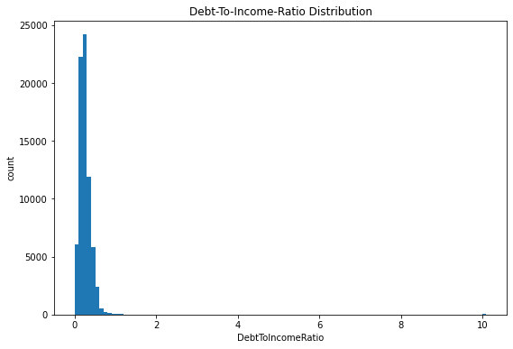

```python
# Standard scale plotting
binsize = 0.1
bins = np.arange(0, loandata_clean['DebtToIncomeRatio'].max()+binsize, binsize)

plt.figure(figsize=[9, 6])
plt.hist(data = loandata_clean, x = 'DebtToIncomeRatio', bins = bins)
plt.xlabel('DebtToIncomeRatio')
plt.ylabel('count')
plt.title('Debt-To-Income-Ratio Distribution')
plt.show()
```

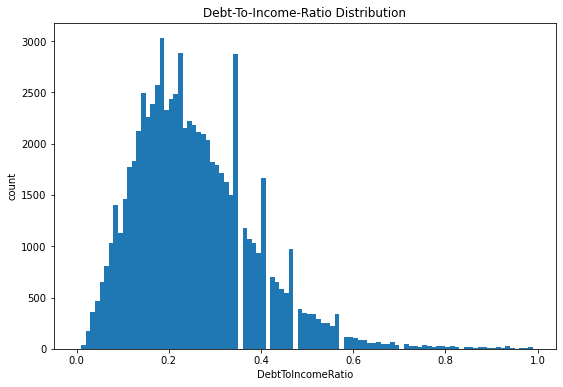

```python
# Using a smaller bin size
bins = np.arange(0,1, 0.01)
plt.figure(figsize=[9, 6])
plt.hist(data = loandata_clean, x = 'DebtToIncomeRatio', bins = bins)
plt.xlabel('DebtToIncomeRatio')
plt.ylabel('count')
plt.title('Debt-To-Income-Ratio Distribution');
```

## Observation

Generally, standard loan lenders prefer a DebtToIncomeRatio that is 36% or lesser, but depending on the type of loan, 50% is a threshold value. From the visuals above, it is observed that there is a large spike around 0.2 and 0.36 indicating that a majority of borrowers have a DebtToIncomeRatio below the threshold value.

## Question 6:

What is the distribution of the ProsperScore?

## Visualization

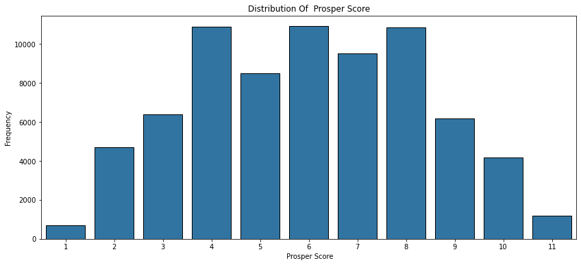

```python
myCountPlot(loandata_clean, 'ProsperScore')
```

## Observation

It is observed that the ProsperScore which assesses risk levels for loan is tri-modal at 4,6 and 8 risk levels.

## Question 7:

How is the Employee Status Duration distributed?

## Visualization

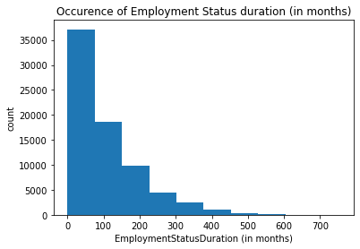

```python
# Plotting a histogram of the EmploymentStatusDuration distribution
plt.hist(data=loandata_clean, x='EmploymentStatusDuration')
plt.xlabel('EmploymentStatusDuration (in months)')
plt.ylabel('count')
plt.title('Occurence of Employment Status duration (in months)');
```

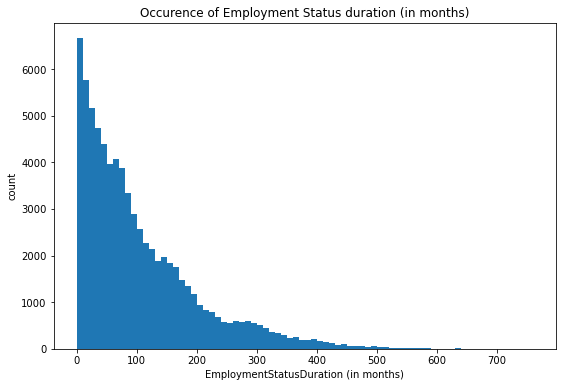

```python
# Standard scale plotting
binsize = 10
bins = np.arange(0, loandata_clean['EmploymentStatusDuration'].max()+binsize, binsize)

plt.figure(figsize=[9, 6])
plt.hist(data = loandata_clean, x = 'EmploymentStatusDuration', bins = bins)
plt.xlabel('EmploymentStatusDuration (in months)')
plt.ylabel('count')
plt.title('Occurence of Employment Status duration (in months)');
plt.show()
```

## Observation

It is observed that the count is highest at the lowest length of the employment status.

## Question 8:

What percentage of borrowers are Home Owners? What is/are their employment status, and what are the occupation of the top borrowers?

## Visualization

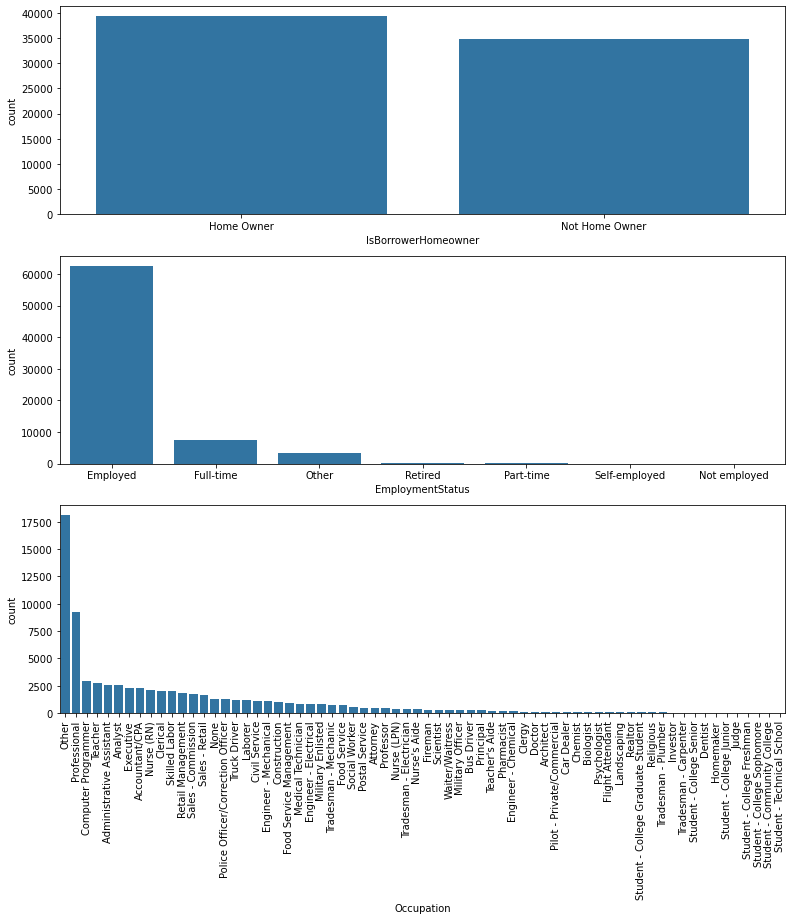

```python
# Plotting all three variables together to get their distribution

fig, ax = plt.subplots(nrows=3, figsize = [13,13])

base_color = sb.color_palette()[0]
sb.countplot(data = loandata_clean, x = 'IsBorrowerHomeowner', order = loandata_clean['IsBorrowerHomeowner'].value_counts().index,
             color = base_color, ax = ax[0])
sb.countplot(data = loandata_clean, x = 'EmploymentStatus', order = loandata_clean['EmploymentStatus'].value_counts().index,
             color = base_color, ax = ax[1])
sb.countplot(data = loandata_clean, x = 'Occupation', order = loandata_clean['Occupation'].value_counts().index,
             color = base_color, ax = ax[2])
plt.xticks(rotation=90);

plt.show()
```

## Observation

### Of the features you investigated, were there any unusual distributions? Did you perform any operations on the data to tidy, adjust, or change the form of the data? If so, why did you do this?

> During investigation of the StatedMonthlyIncome variable, outliers were observed, which seeemed unlikely to be Monthly Income. These outliers were dealt with and the shape of the dataframe before and after were noted down. Also, during the DebtToIncomeRatio investigation, the plot was scaled to focus on a range of 0.1 to 1.0 to discover more insights.

## Bivariate Exploration

## Question 9:

How does Prosper Score affect Loan Amount?

## Visualization

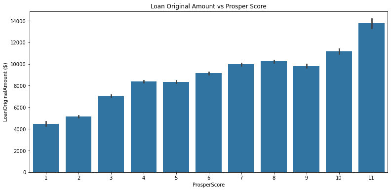

```python
plt.figure(figsize=[13,6])
base_color = sb.color_palette()[0]
sb.barplot(data=loandata_clean, x='ProsperScore', y='LoanOriginalAmount', color=base_color)
plt.ylabel('LoanOriginalAmount ($)');
plt.title('Loan Original Amount vs Prosper Score');
```

## Observation

It can be seen from the visual above that the Loan Original Amount increases as the Prosper Score increases, indicating that low or no risk borrowers have higher chances of getting larger Loan Amounts.

## Question 10:

Is there a relationship/correlation between Monthly Loan Payment and Loan Original Amount?

## Visualization

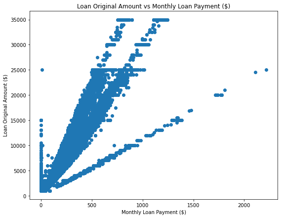

```python
# Using a scatterplot to determine if there is a correlation between MonthlyLoanPayment and LoanOriginalAmount
plt.figure(figsize = [9, 7])
plt.scatter(data = loandata_clean, x = 'MonthlyLoanPayment', y = 'LoanOriginalAmount')
plt.xlabel('Monthly Loan Payment ($)')
plt.ylabel('Loan Original Amount ($)')
plt.title('Loan Original Amount vs Monthly Loan Payment ($)')
plt.show()
```

## Observation

The visuals above shows that there is a strong positive relationship/correlation between Loan Original Amount and Monthly Loan Payment. And also, the plot is seen to be split into three lines. This might be further exlored using a multivariate plot.

## Question 11:

Does the Prosper Score affect the Loan Original Amount?

## Visualization

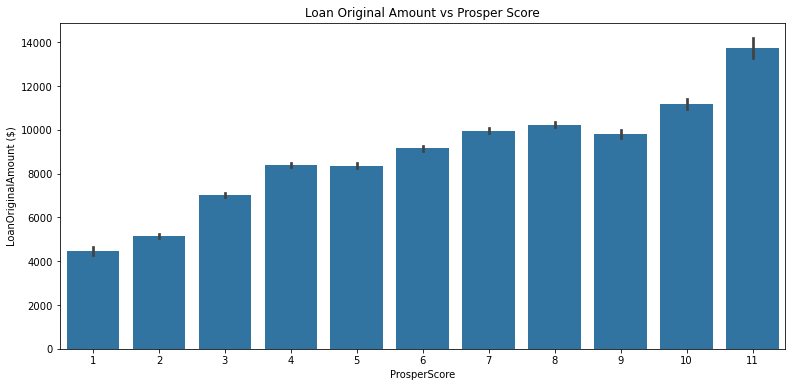

```python
plt.figure(figsize=[13,6])
base_color = sb.color_palette()[0]
sb.barplot(data=loandata_clean, x='ProsperScore', y='LoanOriginalAmount', color=base_color)
plt.ylabel('LoanOriginalAmount ($)')
plt.title('Loan Original Amount vs Prosper Score');
```

## Observation

It can be seen from the visual above that the Loan Original Amount increases as the Prosper number increases(or Prosper risk reduces), showing that low risk borrowers have a higher chance of getting larger loan amount.

## Question 12:

Does having a home aid or help in securing more loand than borrowers without homes?

## Visualization

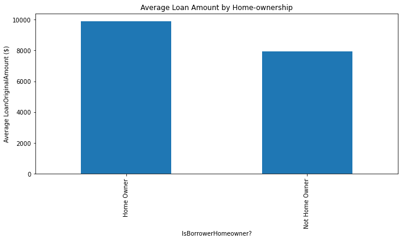

```python
# Plotting average Loan Amount by IsBorrowerHomeowner
data = loandata_clean.groupby('IsBorrowerHomeowner').mean()['LoanOriginalAmount']
# Creating a plot as the variable "ax"
ax = data.plot(kind='bar',
               title="Average Loan Amount by Home-ownership",
               figsize = (11,5), color=base_color)
ax.set(xlabel='IsBorrowerHomeowner?',
       ylabel='Average LoanOriginalAmount ($)');
```

## Observation

The plot evidently shows that borrowers that are home owners get more loans that borrowers that are not home owners.

### Talk about some of the relationships you observed in this part of the investigation. How did the feature(s) of interest vary with other features in the dataset?

> There was a positive linear correlation/relationship observed between LoanOriginalAmount and MonthlyLoanPayment, as the scatterplot showed three lines. There was also a relationship observed between LoanOriginalAmount and some categorical features, as more loans are associated with borrowers with low risk i.e. high Prosper Score and owning a home.

## Multivariate Exploration

## Question 13:

Is there a third variable from the positive correlation earlier between Loan Original Amount and Monthly Loan Payment?

## Visualization

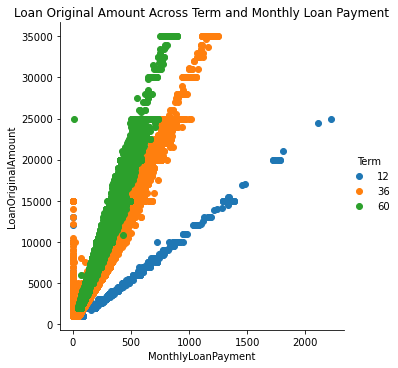

```python
g = sb.FacetGrid(data = loandata_clean, hue = 'Term', height = 5)
g.map(plt.scatter, 'MonthlyLoanPayment', 'LoanOriginalAmount')
plt.title('Loan Original Amount Across Term and Monthly Loan Payment')
g.add_legend();
```

## Observation

From the visual above, it can be seen that there is a third variable (Loan Term) involved, showing that borrowers with longer loan Term 36 and 60 months, receives higher loan amount than borrowers with loan Term 12 months. Also, as shown in the visual, the scheduled monthly payment for a longer loan Term is less than that of small loan Term.

## Question 14:

How does the Loan Original Amount affect the Prosper Score?

## Visualization

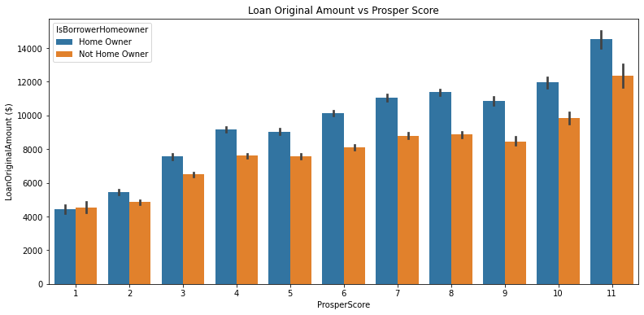

```python
plt.figure(figsize=[13, 6])
base_color=sb.color_palette()[0]
sb.barplot(data=loandata_clean, x='ProsperScore', y='LoanOriginalAmount', hue='IsBorrowerHomeowner')
plt.ylabel('LoanOriginalAmount ($)')
plt.title('Loan Original Amount vs Prosper Score');
```

## Observation

The visual above shows that Home Owners with a good Prosper Score are likely to get a large Loan Amount.

## Question 15:

How does Loan Term and Prosper Score affect tha Loan Amount to be given?

## Visualization

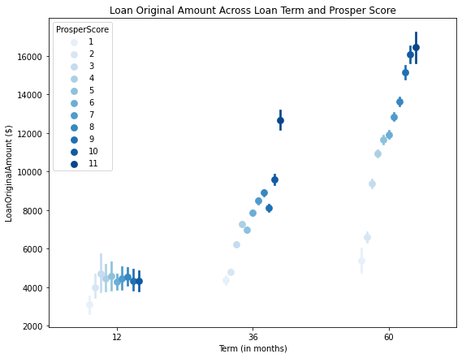

```python
fig = plt.figure(figsize = [9,7])
ax = sb.pointplot(data = loandata_clean, x = 'Term', y = 'LoanOriginalAmount', hue = 'ProsperScore',
           palette = 'Blues', linestyles = '', dodge = 0.4)
plt.title('Loan Original Amount Across Loan Term and Prosper Score')
plt.ylabel('LoanOriginalAmount ($)')
plt.xlabel('Term (in months)')
plt.show();
```

## Observation

The visual above shows that a borrower is more likely to get a large Loan Amount if the Loan Term and the Prosper Score are higher.

### Talk about some of the relationships you observed in this part of the investigation. Were there features that strengthened each other in terms of looking at your feature(s) of interest?

> The Monthly Loan Payment that was observed to be positively correlated with Loan Original Amount was strenghtened with Loan Term, as it is an important factor in issuing out loans with larger loan amounts being issued out for longer term.

### Were there any interesting or surprising interactions between features?

> There were no interesting or surprising interactions between features except for the one observed in the Loan Term scatterplot, as for each Loan Term, subplots could be created to show how it affects loan amount.